# Mar 26 Class FAQ

Elgar Teo

April 07, 2021

You should take the lecture first before reading this FAQ, since some of the examples below are borrowed from the in-class activities.

## CSV Files

We often deal with CSV files in this course. But what exactly are they? CSV refers comma-separated values. As its name implies, it stores values with comma separation. To understand its structure, let us create a very simple data frame, and save it as a CSV file:

```r
test <- data.frame(
  name = c("Peter", "John", "Mary"),
  age = c(14, 18, 17),
  gender = c("M", "M", "F")
)
write.csv(test, "test.csv", row.names = FALSE) # save data frame as CSV file
```

Now, right-click on the CSV file and open it in Notepad (Windows)/TextEdit (macOS). This reveals the structure of a CSV file:

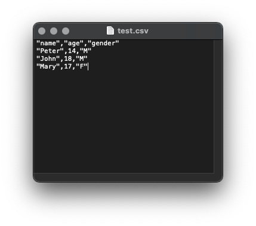

As you can see, each line of the text corresponds to each row in the data frame (including the header row), and values in each column is separated by commas. This is what comma-separated values mean. By utilizing just commas and line breaks, CSV files store data in a table structure in plain text.

You may wonder, why don’t just use Excel file instead? It is because Excel file is a proprietary format, meaning that it is solely-owned by Microsoft and only Microsoft knows how to read it 100% accurately (yes, there are some other software that can read Excel files but they are not 100% reliable, especially for files involving complex formatting). Unlike CSV file, you cannot just read an Excel file using Notepad/TextEdit. This is why CSV files are widely used for passing external data into R (yes, there are R packages that can read Excel files, but again they are not very reliable).

Of course, it’d be counter-intuitive to edit CSV files comma-by-comma using Notepad/TextEdit if we want to pass data into R. You can use Excel or Numbers in macOS. But when you save the file, remember to save/export it as a CSV file:

[figure not shown]

In the in-class project, the following code is used to read the CSV file of the COVID-19 confirmed cases:

```r
dxy_cc <- read.csv("https://raw.githubusercontent.com/globalcitizen/2019-wuhan-coronavirus-data/master/data-sources/dxy/data/20200319-013132-dxy-2019ncov-data.csv",sep="|",skip=3,header=F,stringsAsFactors = F)
```

What do the extra arguments do? You can ignore `stringAsFactor = F`, since it is only necessary for R version older than 4.0.

If we download the [file](https://raw.githubusercontent.com/globalcitizen/2019-wuhan-coronavirus-data/master/data-sources/dxy/data/20200319-013132-dxy-2019ncov-data.csv) and open it using Notepad/TextEdit:

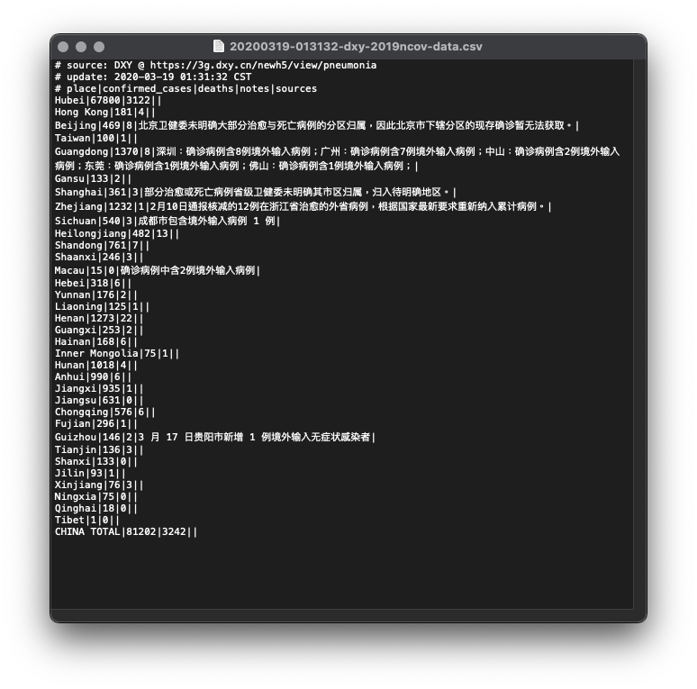

There are two major differences from an ordinary CSV file:

1. The file uses vertical bars `|` instead of commas to separate values
2. The first three lines of the file are not part of the table

Thus, we need to specify `sep = "|"` to indicate that this CSV file uses `|` to separate values and `skip = 3` to skip the first three lines in order to read the file properly into R.

There exists other variants of CSV, such as TSV that uses tab spacing `\t` to separate values. The same principle applies when dealing with these files.

## `match()`

The in-class project uses the following code:

```r
# Add two new columns to the OGR data
chn_adm$confirmed_cases <- dxy_cc$confirmed_cases[match(as.character(chn_adm$NAME_1),dxy_cc$Place)]
chn_adm$deaths <- dxy_cc$deaths[match(as.character(chn_adm$NAME_1),dxy_cc$Place)]
```

`match()` is something new. The documentation (via `?match`) actually tells you that `%in%` and `match()` are closely related. Recall `%in%`:

```r
1:10 %in% c(3, 1, 5)
```

```
##  [1]  TRUE FALSE  TRUE FALSE  TRUE FALSE FALSE FALSE FALSE FALSE
```

It tells you which of the element on the left hand side is a member of the vector on the right hand side in a logical vector. `match()` performs similar task, but it returns the corresponding index number instead:

```r
match(1:10, c(3, 1, 5))
```

```
##  [1]  2 NA  1 NA  3 NA NA NA NA NA
```

The first element of the output is `2`, because `1` is the second element of the vector on the right, and so forth. `NA` indicates that the value is not a member of the vector on the right.

From the example above, we can know that `match()` tells you where each value is located in a vector. In the in-class project, we have two data sources, and we need to merge them by the province. In essence, we have two identical vector but in different sequence. We need to know how each element of one vector corresponds to the other vector. `match()` does exactly that by telling us how one vector is sorted in another vector, like the following example:

```r
match(1:10, 10:1)
```

```
##  [1] 10  9  8  7  6  5  4  3  2  1
```

The code tells use how each of the element from the vector on the left is sorted in the vector on the right. By the same token, the code in the in-class project `match(as.character(chn_adm$NAME_1), dxy_cc$Place)` tell us how to sort the provinces in `dxy_cc` like the way it is in `chn_adm` in terms of index numbers, and by plugging in the sorted index numbers into `dxy_cc$confirmed_cases[...]`, we can obtain the number confirmed cases sorted by how the province is sorted in `chn_adm`.

## `"["`

In the part that extracts the coordinates from Twitter API data, the following code is used:

```r
## Extract the coordinates
t_geo <- t(sapply(tweet$geo_coords,"["))
## Remove all NA rows
with_coord <- !is.na(t_geo[,1])
lat_lon <- data.frame(lat=t_geo[with_coord,1],lng=t_geo[with_coord,2])
```

The line with the `"["` is particularly confusing because it utilizes a shorthand that involves some advanced concepts in R. Indeed, we can actually do the same thing without using this shorthand. But first of all, let us look at what is the problem that we need to tackle.

The data frame returned by `rtweet` contains the geographical coordinates of the tweets under the column `geo_coords`. As we know, coordinates are made up of longitude and latitude, so how are they stored in a single column instead of two? Let’s check the class of the `geo_coords` column:

```r
tweet <- search_tweets(" ", n = 10000, geocode = "22.39,114.14,10000mi")
class(tweet$geo_coords)
```

```
## [1] "list"
```

Instead of being numeric, the column is a list. It is because each element of a numeric vector can only hold one value, and there is no such restriction for a list. The first and second element is the latitude and longitude respectively, and to access them:

```r
# latitude
tweet$geo_coords[[1]][1]
```

```
## [1] NA
```

```r
# longitude
tweet$geo_coords[[1]][2]
```

```
## [1] NA
```

But list is inconvenient to work with. It is better to convert it into a data frame with two columns holding the latitude and longitude separately to make things easier, e.g., plotting the locations on a map.

How do we do that? We know that each element of the list contains two element, in which the first is the latitude and the second is the latitude. Therefore, we can use `lapply()` to go through the list one-by-one to extract the coordinates, and then use the coordinates to form a data frame:

```r
lat_lon <- lapply(tweet$geo_coords, function(x) {
  data.frame(lat = x[1], lng = x[2]) # go through each element and create a data frame with lat and lng columns
})
lat_lon <- do.call("rbind", lat_lon) # bind all the data frames by row
lat_lon <- lat_lon[!is.na(lat_lon$lat), ] # remove rows without coordinates
lat_lon
```

```
##           lat      lng
## 2725 13.25889 123.4953
## 2726 17.62694 120.8322
## 2727 16.28300 120.4830
## 5221 14.64390 121.0370
## 5972 14.64390 121.0370
## 6694 11.95000 121.9330
```

This `lat_lon` data frame is exactly the same as the one created by the code used in the in-class project, but this approach should be way more comprehensible.

## Shapefile

Shapefile is a file format that contains geographical graphics. The name “shapefile” is actually a bit misleading. Instead of being a file, it is a collection of files. When you import a shapefile into R using `readOGR("xxx.shp")`, it actually goes through the entire folder where `"xxx.shp"` is located and reads all the necessary files. Therefore, you should treat the entire folder as a single shapefile and do not delete or move any of its files.

Shapefile supports attributions, meaning that it does not only contain the graphics but also the labels that can help human understand what the graphics are about. In the case of the shapefile of China, the attributes are the names of the provinces. And in R, the attributions of the shapefile are stored in a data frame. To view the attributions as a data frame in RStudio, you can use the following command:

```r
chn_adm <- readOGR("./CHN_adm/CHN_adm1.shp", layer = "CHN_adm1", GDAL1_integer64_policy = TRUE)
View(chn_adm@data)
```

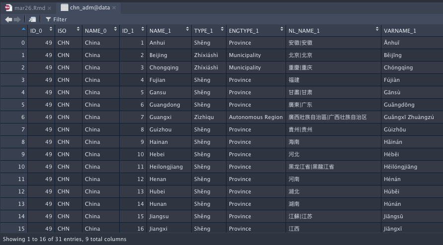

Each row in this data frame corresponds to each graphical components of the shapefile. In this case, the components are the provinces of China. To add an additional attribute, we can simply append a new column. This is exactly what the following code from the in-class project is doing:

```r
# Add two new columns to the OGR data
chn_adm$confirmed_cases <- dxy_cc$confirmed_cases[match(as.character(chn_adm$NAME_1),dxy_cc$Place)]
chn_adm$deaths <- dxy_cc$deaths[match(as.character(chn_adm$NAME_1),dxy_cc$Place)]
```

## Colour palettes

The following code is used to specify the colours of the map:

```r
pal_m <- colorBin(palette="Reds",bin = c(0,100,500,1000,2000,5000,10000,20000,40000,60000,80000), domain=chn_adm$confirmed_cases)
m <- addPolygons(m,data=chn_adm,weight = 1,popup=~pop_up,color = ~pal_m(chn_adm$confirmed_cases))
```

How does `pal_m()` do that? It follows a set of rules that are specified when `pal_m()` is created by `colorBin()`. In this sense, `colorBin()` is a function that creates function.

`leaflet` provides four of such “palette function generators”: `colorBin()`, `colorNumeric()`, `colorQuantile()` and `colorFactor()`. They are used for different types of data. There is a very detailed and clear [documentation](https://rstudio.github.io/leaflet/colors.html) explaining how each of these functions work and when you should use them.

The `palette` argument in the “palette function generators” can be the name of the colour tone, such as `"Reds"` as shown above, or a string of colour codes. There is a package `RColorBewer` that provides a wide range of ready-to-use palettes. You can refer to this [guide](https://www.datanovia.com/en/blog/the-a-z-of-rcolorbrewer-palette/) for more details.

An example code of how to use a palette from `RColorBewer` to colour maps:

```r
pal_m <- colorBin(
  palette = brewer.pal(n = 11, name = "Paired"), # use the palette "Paired"
  bin = c(0, 100, 500, 1000, 2000, 5000, 10000, 20000, 40000, 60000, 80000),
  domain = chn_adm$confirmed_cases
)
```